# 09-finalmodel

Wenzel Hackeng

22/10/2020

First call the required packages

```r
library('caret')
library('splitstackshape')
library('matrixStats')
library('randomForest')
library('glmnet')
library('ggtern')
library('tidyverse')
library('cowplot')
library('ggsci')
library('ggpubr')
```

# Functions for analyses

```r
# Function determine most variable positions by downsampling with 3 repeats, function requires MatrixStats and caret
DownSampMVP<-function(df){
  downsampnames<-list()
  # three random downsamples on only groups and sample names for speed.
  df$RowNames<-rownames(df)
  for(i in 1:3){
      downsampnames[[i]]<-downSample(df[,"RowNames"],df[,"Sample_Group"], list=FALSE)
  }

  # Lapply merge with beta values, remove first two columns (names and class), and transpose. Sample names are     not relevant as searching for the most variable positions.
  downsamples<-lapply(downsampnames,function(x,y){merge(x, y, by.x=names(x)[1], by.y="RowNames")},df[,!names(df) %in% c("Sample_Group")])
  downsamples<-lapply(downsamples, "[", -c(1, 2))
  downsamples<-lapply(downsamples,function(x){t(x)})

  # Inefficient way of ordering probes by mean absolute standard deviation
  a<-downsamples[[1]]
  b<-downsamples[[2]]
  c<-downsamples[[3]]
  amads=apply(a,1,mad)
  bmads=apply(b,1,mad)
  cmads=apply(c,1,mad)
  amergedmad<-as.data.frame(a[rev(order(amads)),])
  bmergedmad<-as.data.frame(b[rev(order(bmads)),])
  cmergedmad<-as.data.frame(c[rev(order(cmads)),])
  amergedmad$ordera<-1:nrow(amergedmad)
  bmergedmad$orderb<-1:nrow(bmergedmad)
  cmergedmad$orderc<-1:nrow(cmergedmad)

  # Selecting probes by the minimal rank of the mean absolute standard deviation over all downsamples.
  MVprobes<-merge(amergedmad, bmergedmad, by.x= "row.names", by.y= "row.names")
  MVprobes<-merge(MVprobes, cmergedmad, by.x= "Row.names", by.y= "row.names")
  rownames(MVprobes) <- MVprobes[,1]
  MVprobes[,1] <-NULL
  MVprobes<-MVprobes[,c("ordera","orderb","orderc")]
  MVprobes$min <- rowMins(as.matrix(MVprobes))
  MVprobes$max <- rowMaxs(as.matrix(MVprobes))
  MVprobes <-MVprobes[order(MVprobes$max, decreasing = FALSE),]
  bestprobesMVP<-MVprobes[1:5000,c("min", "max")]
  return(bestprobesMVP)
}

# Functions to add annotation data to MVP and Test and change to trainvalMVPs to numeric
prepMVP<-function(df){
  dfx<-as.data.frame(t(df))
  dfx[]<-lapply(dfx, function(x) as.numeric(as.character(x)))
  MVPdata<- merge(pd, dfx, by.x="Sample_Name", by.y = "row.names", sort = FALSE)
  rownames(MVPdata)<-MVPdata[,1]
  MVPdata[,1]<-NULL
  return(MVPdata)
}
# Function for Random forest with with downsampling for number of group cases
RFdownsamp<-function(x){ # x = trainval set
  temp<-summary(x[["Sample_Group"]])
  Smallesttemp<-min(temp)
  Groupstemp<-length(temp)
  MVPmodeltemp<-randomForest(Sample_Group~.,data=x, ntree=Trees, mtry = sqrt(ncol(x)-1), importance=TRUE, sampsize=rep(Smallesttemp, Groupstemp))
  oob<-tail(MVPmodeltemp$err.rate[,1], n=1)
  return(list(RFmodel=MVPmodeltemp, OOBerror=oob))
}

# Function nested CV lambda 1se
nestCVlambda<-function(x){ # x= rfmodel
  model<-x # input RF model
  votes<-model$votes # get raw scores for fit_score file
  origin<-as.data.frame(model$y)
  colnames(origin)[1] <- "Origin"
  fit_score<-merge(votes, origin, by.x = "row.names", by.y = "row.names")
  row.names(fit_score)<-fit_score[,1]
  fit_score[,1]<-NULL
  # make matrix
  x <- model.matrix(Origin~., fit_score)[,-1]
  # Convert the outcome (class) to a numerical variable
  y <- as.factor(fit_score$Origin)
  # try different lambda ridge penalties in 3fold cross validation
  cv <- cv.glmnet(x, y, family = "multinomial", alpha = Alpha, nfolds = Nfolds)
  # L2 ridge regression regression model with best lambda
  L2reg_model <- glmnet(x, y, family = "multinomial",  alpha = Alpha, lambda = cv[[Lambda]])
  return(list(Ridgemodel=L2reg_model, Lmin = cv$lambda.min, L1se = cv$lambda.1se))
}


# Function to test RF in Testfold
TestRFprediction<-function(x, y, z) { # x = RFmodel, y = new data, z = true sample group
  TestRFprediction<-predict(x, y, type = 'response')
  TestRFvotes<-predict(x, y, type = 'vote')
  OutputResponse<-(table(TestRFprediction, actual = z))
  rf_acc_calc<-data.frame(as.character(z),as.character(TestRFprediction),stringsAsFactors=FALSE)
  Accuracy=sum(rf_acc_calc[,1]==rf_acc_calc[,2], na.rm = TRUE)/nrow(rf_acc_calc)
  return(list(Table = OutputResponse, Accuracy = Accuracy, Votes = TestRFvotes, Prediction = TestRFprediction))
}

# Function to test LR model in Testfold
TestLRprediction<-function(x, y, z){ # x = LRmodel, y = RF votes of new data, z = true sample group
  TestLRprediction<-predict(x, newx = y, s = Lambda, type = "class")
  TestLRprob<-predict(x, newx = y, s = Lambda, type = "response")
  OutputResponse<-(table(TestLRprediction, actual = z))
  lr_acc_calc<-data.frame(as.character(z),as.character(TestLRprediction),stringsAsFactors=FALSE)
  Accuracy=sum(lr_acc_calc[,1]==lr_acc_calc[,2], na.rm = TRUE)/nrow(lr_acc_calc)
  return(list(Table = OutputResponse, Accuracy = Accuracy, Prob = TestLRprob, Prediction = TestLRprediction))
}

# Function impute beta values
impute_random <- function(mat){
  stopifnot(is.matrix(mat))

  if (all(is.na(mat))) {
    warning("No non-NA data points, returning object unchanged")
    na_num <- nrow(mat)
    return(list(imputed = mat, n = na_num))
  } else {
    na_pos <- is.na(mat)
    na_num <- sum(na_pos)
    mat[na_pos] <- sample(x = mat[!na_pos], size = na_num, replace = TRUE)
    return(list(imputed = mat, n = na_num))
  }
}
```

# Load data

```r
load('./01_preprocessing/PreProcessedDataSets/GEOMERGED/GEOMERGED.rData')
load('./01_preprocessing/PreProcessedDataSets/UMCU/preprocessedUMCU.rData')
load('./01_preprocessing/PreProcessedDataSets/SIotherGSE73832/preprocessedSIotherGSE73832.rData')
load('./01_preprocessing/PreProcessedDataSets/GSE53051/preprocessedPancreasCasesGSE53051.rData')
load('./01_preprocessing/PreProcessedDataSets/GSE134089/preprocessedGSE134089.rData')
load('./01_preprocessing/PreProcessedDataSets/GIotherGSE73832/preprocessedGIotherGSE73832.rData')
load('./01_preprocessing/PreProcessedDataSets/EGAD00010001720/preprocessedEGAD00010001720.rData')
PD_data_tcga_primaries <- readRDS("./RAW/TCGA/Tumor/PD_data-tcga-primaries.rds")
data_tcga_primaries <- as.data.frame(readRDS("./RAW/TCGA/Tumor/data-tcga-primaries.rds"))
PD_data_tcga_normal <- readRDS("./RAW/TCGA/Normal/tcga-normal-metadata.rds")
data_tcga_normal <- as.data.frame(readRDS("./RAW/TCGA/Normal/tcga-normal-data.rds"))

EPIC_probes<-read_csv("./RAW/infinium-methylationepic-v-1-0-b5-manifest-file.csv", col_types = cols(Coordinate_36 = col_character()),
    skip = 7)[,c(1,2)]
PD_combined<-read.csv("./PD_FILES/PD_combined.csv", header=TRUE)
PD_onlinetestcohort<-read.csv("./PD_FILES/PD_onlinetestcohort.csv", header=TRUE)
PD_localtestcohort<-read.csv("./PD_FILES/PD_localtestcohort.csv", header=TRUE)
PD_otherNENcohort<-read.csv("./PD_FILES/PD_otherNENcohort.csv", header=TRUE)
```

# Prepare data

General preparing of data for further analysis.

```r
# merge 450k and EPIC to select overlapping and complete probes
EPIC_probes[,1]<-"x"

# merge 450k training cohort data and EPIC manifest probes to select overlapping probes
input<-merge(EPIC_probes, merged, by.x="Name", by.y="row.names")
rownames(input) <- input[,1]
GEO_overlap_probes <- input[,1:2]
input[,1:2] <- NULL

# prepare sample group data training data
pd<-PD_combined[1:69,]
pd$Sample_Group<-as.factor(as.character(pd$Sample_Group))
pd<-pd[,c("Sample_Name","Sample_Group")]

# Merge the annotation with betas training cohort
annoinput<-merge(t(input), pd, by.x="row.names", by.y="Sample_Name")
rownames(annoinput)<-annoinput[,1]
annoinput[,1]<-NULL
```

```r
Seed<-13 # for repeatability
set.seed(Seed)
# prepare UMCU test cohort and randomly impute missings
UMCU_test_partition<-as.data.frame(mynormUMCU[, names(as.data.frame(mynormUMCU)) %in%
c("1LCasePan","2LCasePan","3LCasePan","4InCasePan","5MCasePan",
"6M2CasePan","Lung_NEN_MEN1","NET-UP","Ileum_met_spor_NET","Ileum_prim_spor_NET","Lung_NEN_sporadic1","Lung_NEN_sporadic2","NET-UP2", "prim-met5In", "prim-met6M1","prim-met6In", "Lung_NEN_sporadic3", "Lung_NEN_sporadic4",  "Lung_NEN_sporadic5", "Lung_NEN_sporadic6", "Lung_met_NEN_sporadic1",
"Lung_NEN_sporadic7", "Lung_NEN_sporadic8", "Lung_NEN_sporadic9",
"Ileum_met_spor_NET2", "Ileum_met_spor_NET3"), drop = F])
UMCU_test_partition<-merge(GEO_overlap_probes, UMCU_test_partition, by.x="Name", by.y="row.names", all=TRUE)
rownames(UMCU_test_partition) <- UMCU_test_partition[,1]
UMCU_test_partition[,1:2] <- NULL
UMCU_test_partition_im<-as.data.frame(impute_random(as.matrix(UMCU_test_partition))[[1]])

# prepare Other Small intestinal NETs and randomly impute missings
SI_Karpathakis_test_partition<-merge(GEO_overlap_probes, as.data.frame(mynormSIotherGSE73832), by.x="Name", by.y="row.names", all = TRUE)
rownames(SI_Karpathakis_test_partition) <- SI_Karpathakis_test_partition[,1]
SI_Karpathakis_test_partition[,1:2] <- NULL #also remove columns from GEO cleas
SI_Karpathakis_test_partition_im<-as.data.frame(impute_random(as.matrix(SI_Karpathakis_test_partition))[[1]])

# prepare Other pancreatic NETs and randomly impute missings
Pan_Timp_test_partition<-merge(GEO_overlap_probes, as.data.frame(GSE53051pancreasbetas), by.x="Name", by.y="row.names", all = TRUE)
rownames(Pan_Timp_test_partition) <- Pan_Timp_test_partition[,1]
Pan_Timp_test_partition[,1:2] <- NULL #also remove columns from GEO cleas
Pan_Timp_test_partition_im<-as.data.frame(impute_random(as.matrix(Pan_Timp_test_partition))[[1]])

# prepare Other pancreatic/SI NETs and randomly impute missings
PanSI_Tirosh_test_partition<-merge(GEO_overlap_probes, mynormGSE134089cases, by.x="Name", by.y="row.names", all = TRUE)
rownames(PanSI_Tirosh_test_partition) <- PanSI_Tirosh_test_partition[,1]
PanSI_Tirosh_test_partition[,1:2] <- NULL #also remove columns from GEO cleas
PanSI_Tirosh_test_partition_im<-as.data.frame(impute_random(as.matrix(PanSI_Tirosh_test_partition))[[1]])

# prepare other pulmonary NETs and randomly impute missings
Pulm_Alcala_test_partition<-merge(GEO_overlap_probes, mynormEGAD00010001720_UNIQ, by.x="Name", by.y="row.names", all = TRUE)
rownames(Pulm_Alcala_test_partition) <- Pulm_Alcala_test_partition[,1]
Pulm_Alcala_test_partition[,1:2] <- NULL #also remove columns from GEO cleas
Pulm_Alcala_test_partition_im<-as.data.frame(impute_random(as.matrix(Pulm_Alcala_test_partition))[[1]])

# prepare TCGA tumors and randomly impute missings
data_tcga_primaries<-merge(GEO_overlap_probes, data_tcga_primaries, by.x="Name", by.y="row.names", all = TRUE)
rownames(data_tcga_primaries) <- data_tcga_primaries[,1]
data_tcga_primaries[,1:2] <- NULL #also remove columns from GEO cleas
data_tcga_primaries_im<-as.data.frame(impute_random(as.matrix(data_tcga_primaries))[[1]])

# prepare TCGA normals and randomly impute missings
data_tcga_normal<-merge(GEO_overlap_probes, data_tcga_normal, by.x="Name", by.y="row.names", all = TRUE)
rownames(data_tcga_normal) <- data_tcga_normal[,1]
data_tcga_normal[,1:2] <- NULL #also remove columns from GEO cleas
data_tcga_normal_im<-as.data.frame(impute_random(as.matrix(data_tcga_normal))[[1]])

# Merge online test betas
temp<-merge(SI_Karpathakis_test_partition_im, Pan_Timp_test_partition_im, by.x="row.names", by.y="row.names")
temp<-merge(temp, PanSI_Tirosh_test_partition_im, by.x="Row.names", by.y="row.names")
onlinetestcohort<-merge(temp, Pulm_Alcala_test_partition_im, by.x="Row.names", by.y="row.names")
rownames(onlinetestcohort) <- onlinetestcohort[,1]
onlinetestcohort[,1] <- NULL
pdonlinetest<-rbind(PD_onlinetestcohort[,c("Sample_Name","Sample_Group")],PD_EGAD00010001720_UNIQ[,c("Sample_Name","Sample_Group")])

inputlocaltest<-UMCU_test_partition_im # the input test dataframe with beta values
pdlocaltest<-PD_localtestcohort[,c("Sample_Name","Sample_Group")]


#  Merge the annotation with betas local test cohort
annoinputlocaltest<-merge(pdlocaltest,t(UMCU_test_partition_im), by.x="Sample_Name", by.y="row.names")
rownames(annoinputlocaltest)<-annoinputlocaltest[,1]
annoinputlocaltest[,1]<-NULL

#  Merge the annotation with betas online test cohort
annoinputonlinetest<-merge(pdonlinetest,t(onlinetestcohort), by.x="Sample_Name", by.y="row.names")
rownames(annoinputonlinetest)<-annoinputonlinetest[,1]
annoinputonlinetest[,1]<-NULL
```

```r
# prepare Other GI NETs and randomly impute missings
Seed<-13 # for repeatability
set.seed(Seed)
GI_Karpathakis_test_partition<-merge(GEO_overlap_probes, as.data.frame(mynormGIotherGSE73832), by.x="Name", by.y="row.names", all = TRUE)
rownames(GI_Karpathakis_test_partition) <- GI_Karpathakis_test_partition[,1]
GI_Karpathakis_test_partition[,1:2] <- NULL #also remove columns from GEO cleas
GI_Karpathakis_test_partition_im<-as.data.frame(impute_random(as.matrix(GI_Karpathakis_test_partition))[[1]])

# prepare Other GI NETs and randomly impute missings
GI_Tirosh_test_partition<-merge(GEO_overlap_probes, mynormGSE134089otherGI, by.x="Name", by.y="row.names", all = TRUE)
rownames(GI_Tirosh_test_partition) <- GI_Tirosh_test_partition[,1]
GI_Tirosh_test_partition[,1:2] <- NULL #also remove columns from GEO cleas
GI_Tirosh_test_partition_im<-as.data.frame(impute_random(as.matrix(GI_Tirosh_test_partition))[[1]])

# Merge test betas
OtherNENcohort<-merge(GI_Karpathakis_test_partition_im, GI_Tirosh_test_partition_im, by.x="row.names", by.y="row.names")

rownames(OtherNENcohort) <- OtherNENcohort[,1]
OtherNENcohort[,1] <- NULL

inputotherNEN<-OtherNENcohort # the input test dataframe with beta values
pdotherNEN<-PD_otherNENcohort[,c("Sample_Name","Sample_Group")]

#  Merge the annotation with betas test cohort
annoinputotherNEN<-merge(pdotherNEN,t(inputotherNEN), by.x="Sample_Name", by.y="row.names")
rownames(annoinputotherNEN)<-annoinputotherNEN[,1]
annoinputotherNEN[,1]<-NULL
```

# Final model NEN-ID

RF model based on most variable positions as determined by the downsampled mean absolute standard deviation, nested crossvalidation to build ridge regression calibration

```r
# general method choices
Seed<-13 # for repeatability
# Random forest indicators
Trees<-500
# Ridge Regression indicators
Lambda<-"lambda.1se" # or lambda.min
Alpha <- 0 # 0 = Ridge regression, 1 = Lasso
Nfolds <- 3 #fold CV


# Making final model on complete training data
set.seed(Seed)

# get MVPs for training cohort sets #9minutes
MVPs<-DownSampMVP(annoinput)

# merge MVPs with trainingsets
MVPsTrain<-merge(MVPs, t(annoinput), by.x= "row.names", by.y= "row.names")
rownames(MVPsTrain) <- MVPsTrain[,1]
MVPsTrain[,1:3] <-NULL
MVPsTrain<-prepMVP(MVPsTrain)

#build final random forest model on online cohort
finalRF<-RFdownsamp(MVPsTrain)

# build ridge logistic regression on raw random forest scores with 3 fold lambda optimization
finalLR<-nestCVlambda(finalRF[["RFmodel"]])

newdir<-"09_finalmodel"
ifelse(!dir.exists(file.path(getwd(), newdir)), dir.create(file.path(getwd(), newdir)), FALSE)
```

```
## [1] FALSE
```

```r
myfile <- file.path(paste0("./09_finalmodel/finalRF_and_LR","seed",Seed,"tr",Trees,"l",Lambda,"a",Alpha,"nf",Nfolds,".rData"))
save(finalRF, finalLR, file = myfile)
```

# Predict cases

```r
### local test cohort
#random forest model (raw scores and class)
predictRFlocaltestcohort<-TestRFprediction(finalRF[["RFmodel"]],annoinputlocaltest[,2:ncol(annoinputlocaltest)],annoinputlocaltest[,"Sample_Group"])

#logistic regression model (probabilities and class)
predictLRlocaltestcohort<-TestLRprediction(finalLR[["Ridgemodel"]], predictRFlocaltestcohort[["Votes"]],annoinputlocaltest[,1])

### online test cohort
#random forest model (raw scores and class)
predictRFonlinetestcohort<-TestRFprediction(finalRF[["RFmodel"]],annoinputonlinetest[,2:ncol(annoinputonlinetest)],annoinputonlinetest[,"Sample_Group"])

#logistic regression model (probabilities and class)
predictLRonlinetestcohort<-TestLRprediction(finalLR[["Ridgemodel"]], predictRFonlinetestcohort[["Votes"]],annoinputonlinetest[,1])

### other NENs cohort
#random forest model (raw scores and class)
predictRFotherNENcohort<-TestRFprediction(finalRF[["RFmodel"]],annoinputotherNEN[,2:ncol(annoinputotherNEN)],annoinputotherNEN[,"Sample_Group"])

#logistic regression model (probabilities and class)
predictLRotherNENcohort<-TestLRprediction(finalLR[["Ridgemodel"]], predictRFotherNENcohort[["Votes"]],annoinputotherNEN[,1])

### tcga cohort tumors
#random forest model (raw scores and class)
predictRFtcgatumorcohort<-TestRFprediction(finalRF[["RFmodel"]],t(data_tcga_primaries_im),PD_data_tcga_primaries$tissue)

#logistic regression model (probabilities and class)
predictLRtcgatumorcohort<-TestLRprediction(finalLR[["Ridgemodel"]], predictRFtcgatumorcohort[["Votes"]],PD_data_tcga_primaries$tissue)

### tcga cohort normals
#random forest model (raw scores and class)
predictRFtcganormalcohort<-TestRFprediction(finalRF[["RFmodel"]],t(data_tcga_normal_im),PD_data_tcga_normal$tissue)

#logistic regression model (probabilities and class)
predictLRtcganormalcohort<-TestLRprediction(finalLR[["Ridgemodel"]], predictRFtcganormalcohort[["Votes"]],PD_data_tcga_normal$tissue)

gc()
```

```
##              used    (Mb) gc trigger    (Mb) limit (Mb)   max used    (Mb)
## Ncells    6795238   363.0   20587871  1099.6         NA   25734838  1374.4
## Vcells 1359592989 10372.9 1795088821 13695.5      16384 1795088821 13695.5
```

# Plot OOB Raw Scores

Density plot for true classes. 95% tolerance ellipse per true class

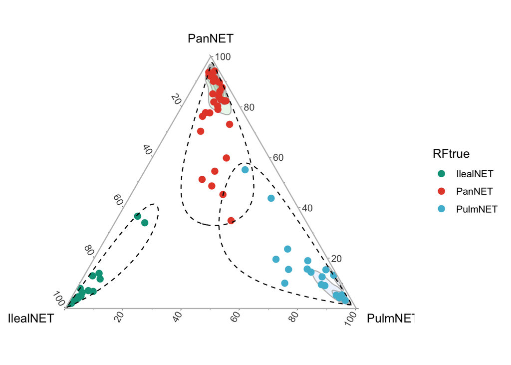

# Plot Calibrated Scores OOB

Density plot for true classes. 95% tolerance ellipse per true class

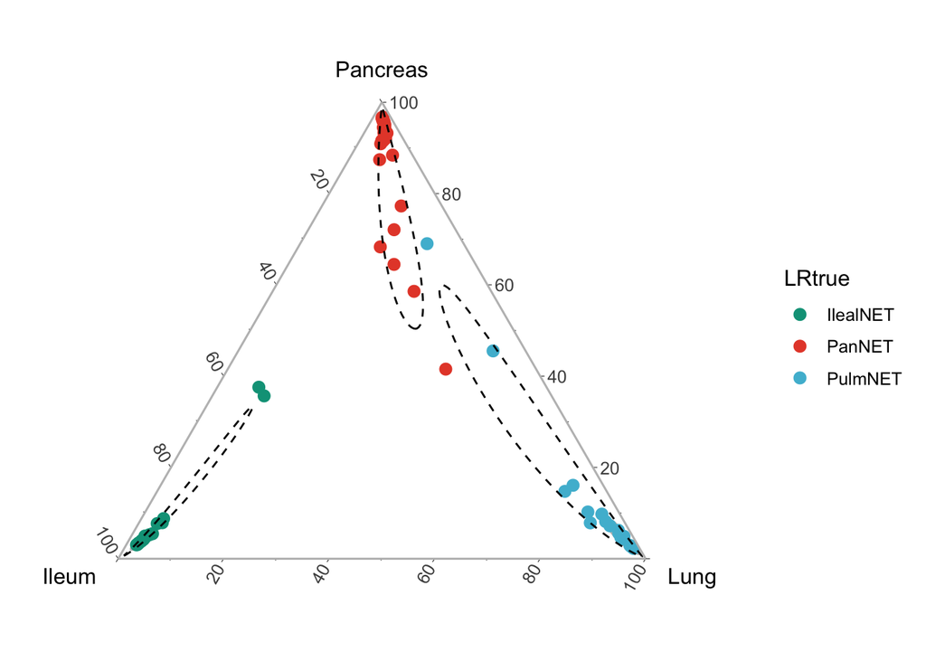

```r
votesLR<-predict(finalLR$Ridgemodel, newx = votesRF, s = Lambda, type = "response")
df<-predict(finalLR$Ridgemodel, newx = votesRF, s = Lambda, type = "class")
trueLR<-as.data.frame(finalRF$RFmodel$y)
colnames(trueLR)[1] <- "LRtrue"
fit_scoreLR<-merge(votesLR, trueLR, by.x = "row.names", by.y = "row.names")
row.names(fit_scoreLR)<-fit_scoreLR[,1]
fit_scoreLR[,1]<-NULL
colnames(fit_scoreLR)<-c("Ileum", "Pancreas", "Lung", "LRtrue")

# ggtern
circle.df4 <- fit_scoreLR %>% filter(LRtrue == "PanNET")
circle.df5 <- fit_scoreLR %>% filter(LRtrue == "IlealNET")
circle.df6 <- fit_scoreLR %>% filter(LRtrue == "PulmNET")

ggtern(data = fit_scoreLR, mapping = aes_string(x = "Ileum", y = "Pancreas", z = "Lung")) +
  scale_color_manual(values = c("#00A087B2","#E64B35B2","#4DBBD5B2"))+
  stat_density_tern(aes(alpha = ..level.., fill = LRtrue),
                    geom = 'polygon',
                    bins = 10,
                    color = "grey",
                    show.legend = FALSE
  ) +
  scale_alpha(guide = 'none')+
  geom_point(aes(color = LRtrue),size = 3, pch=16, alpha = 1)+
  geom_confidence_tern(data = circle.df4, color="black", alpha = 1, linetype = 2,   breaks = c(0.95))+
  geom_confidence_tern(data = circle.df5, color="black", alpha = 1, linetype = 2,   breaks = c(0.95))+
  geom_confidence_tern(data = circle.df6, color="black", alpha = 1, linetype = 2,   breaks = c(0.95))+
  theme_rotate()+
  theme_classic()+
  theme(
    axis.line = element_line(colour = "grey"),
    legend.key=element_blank(),
    legend.background=element_blank())+
  labs(fill = "True Class")
```

# Plot raw scores online test cohort with training set OOB calibrated tolerance ellipse

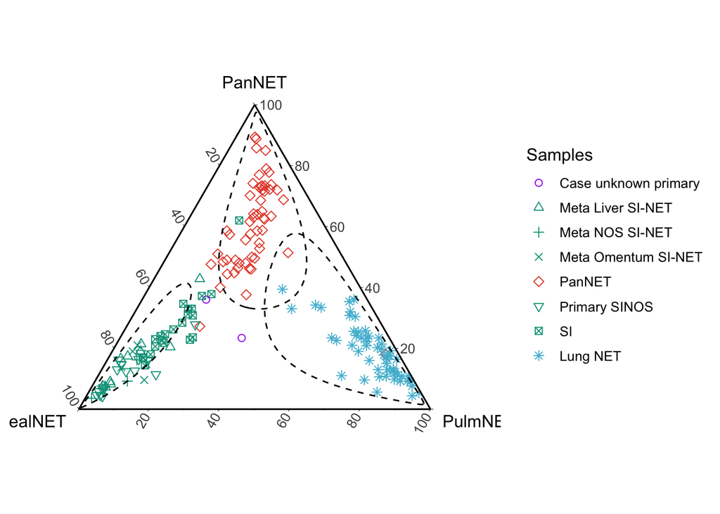

```r
onlineTestRFprob<-as.data.frame(predictRFonlinetestcohort$Votes)
colnames(onlineTestRFprob)<-c("IlealNET", y = "PanNET", z = "PulmNET")
ggtern(data = onlineTestRFprob, mapping = aes_string("IlealNET", y = "PanNET", z = "PulmNET"))+
     geom_point(aes(color = factor(annoinputonlinetest[,"Sample_Group"]), shape = factor(annoinputonlinetest[,"Sample_Group"])),size = 2, alpha =1)+
  scale_alpha(guide = 'none')+
  geom_confidence_tern(data = circle.df1, color="black", alpha = 1, linetype = 2,   breaks = c(0.95))+
  geom_confidence_tern(data = circle.df2, color="black", alpha = 1, linetype = 2,   breaks = c(0.95))+
  geom_confidence_tern(data = circle.df3, color="black", alpha = 1, linetype = 2,   breaks = c(0.95))+
  theme_classic()+
  scale_shape_manual(labels = c("Case unknown primary", "Meta Liver SI-NET", "Meta NOS SI-NET", "Meta Omentum SI-NET", "PanNET", "Primary SINOS", "SI", "Lung NET"),values=1:nlevels(annoinputonlinetest[,"Sample_Group"]))+
  scale_color_manual(labels = c("Case unknown primary", "Meta Liver SI-NET", "Meta NOS SI-NET", "Meta Omentum SI-NET", "PanNET", "Primary SINOS", "SI", "Lung NET"), values = c("purple", "#00A087B2","#00A087B2","#00A087B2", "#E64B35B2", "#00A087B2", "#00A087B2","#4DBBD5B2"))+
  labs(color="Samples", shape="Samples")
```

```r
ggsave("onlineTestcohortRFzoomfar.eps", path = "./09_finalmodel/", width = 30,
  height = 20,
  units = "in")
ggsave("onlineTestcohortRFzoomclose.eps", path = "./09_finalmodel/", width = 6,
  height = 4,
  units = "in")
```

# Plot calibrated scores online test cohort with training set OOB calibrated tolerance ellipse

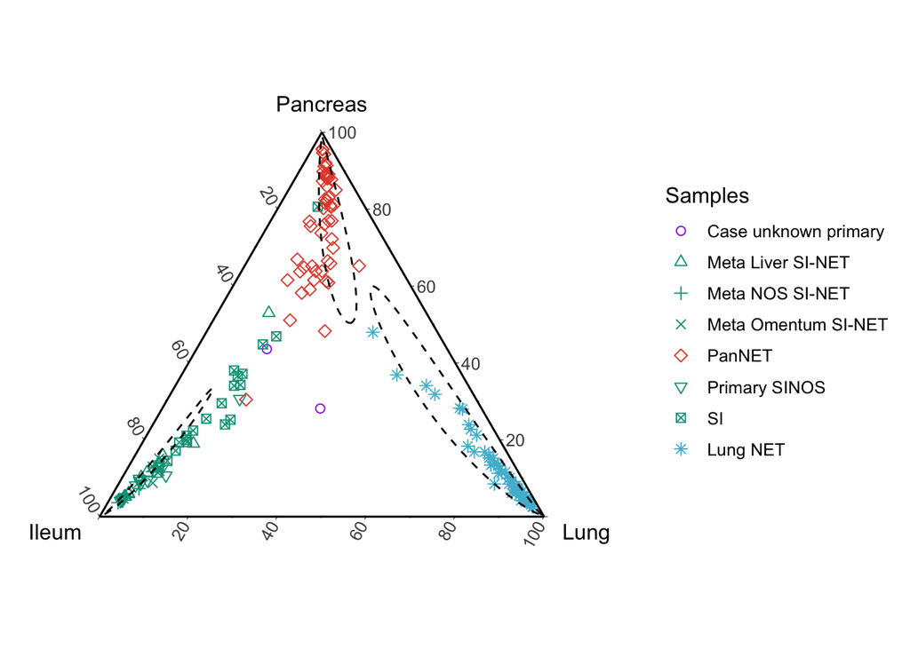

```r
onlineTestLRprob<-as.data.frame(predictLRonlinetestcohort$Prob)
colnames(onlineTestLRprob)<-c("Ileum", "Pancreas", "Lung")
ggtern(data = onlineTestLRprob, mapping = aes_string(x = "Ileum", y = "Pancreas", z = "Lung"))+
  geom_point(aes(color = factor(annoinputonlinetest[,"Sample_Group"]), shape = factor(annoinputonlinetest[,"Sample_Group"])),size = 2, alpha =1)+
  scale_alpha(guide = 'none')+
  geom_confidence_tern(data = circle.df4, color="black", alpha = 1, linetype = 2,   breaks = c(0.95))+
  geom_confidence_tern(data = circle.df5, color="black", alpha = 1, linetype = 2,   breaks = c(0.95))+
  geom_confidence_tern(data = circle.df6, color="black", alpha = 1, linetype = 2,   breaks = c(0.95))+
  theme_classic()+
  scale_shape_manual(labels = c("Case unknown primary", "Meta Liver SI-NET", "Meta NOS SI-NET", "Meta Omentum SI-NET", "PanNET", "Primary SINOS", "SI", "Lung NET"),values=1:nlevels(annoinputonlinetest[,"Sample_Group"]))+
  scale_color_manual(labels = c("Case unknown primary", "Meta Liver SI-NET", "Meta NOS SI-NET", "Meta Omentum SI-NET", "PanNET", "Primary SINOS", "SI", "Lung NET"), values = c("purple", "#00A087B2","#00A087B2","#00A087B2", "#E64B35B2", "#00A087B2", "#00A087B2","#4DBBD5B2"))+
  labs(color="Samples", shape="Samples")
```

```r
ggsave("onlineTestcohortLRzoomfar.eps", path = "./09_finalmodel/", width = 30,
  height = 20,
  units = "in")
ggsave("onlineTestcohortLRzoomclose.eps", path = "./09_finalmodel/", width = 6,
  height = 4,
  units = "in")
```

```r
table(annoinputonlinetest[,"Sample_Group"],predictLRonlinetestcohort$Prediction)
```

```
##
##                  IlealNET PanNET PulmNET
##   CaseUP                1      1       0
##   LiverMet SINOS        9      1       0
##   Met SINOS             5      0       0
##   OmenMet SINOS         6      0       0
##   Pancreas              1     53       1
##   Primary SINOS        16      0       0
##   SI                   19      3       0
##   PulmNET               0      1      55
```

# Plot raw scores local test cohort with training set OOB calibrated tolerance ellipse

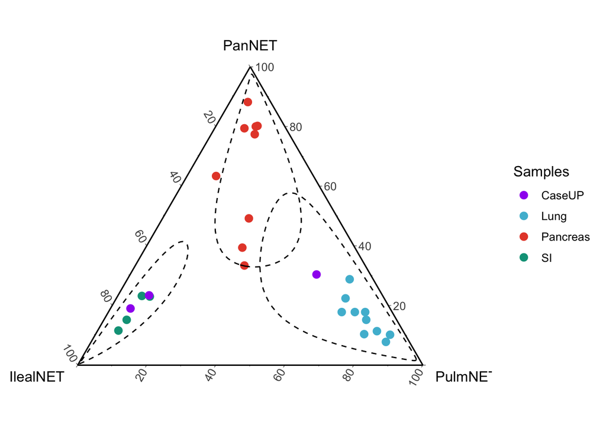

```r
localTestRFprob<-as.data.frame(predictRFlocaltestcohort$Votes)
colnames(localTestRFprob)<-c("IlealNET", y = "PanNET", z = "PulmNET")
ggtern(data = localTestRFprob, mapping = aes_string("IlealNET", y = "PanNET", z = "PulmNET"))+
  scale_color_manual(values = c("purple", "#4DBBD5B2","#E64B35B2","#00A087B2"))+
    geom_point(aes(color = annoinputlocaltest[,"Sample_Group"]),size = 3, pch=16, alpha = 1)+
  scale_alpha(guide = 'none')+
  geom_confidence_tern(data = circle.df1, color="black", alpha = 1, linetype = 2,   breaks = c(0.95))+
  geom_confidence_tern(data = circle.df2, color="black", alpha = 1, linetype = 2,   breaks = c(0.95))+
  geom_confidence_tern(data = circle.df3, color="black", alpha = 1, linetype = 2,   breaks = c(0.95))+
  theme_classic()+
  labs(color="Samples")
```

```r
ggsave("localTestcohortRFzoomfar.eps", path = "./09_finalmodel/", width = 30,
  height = 20,
  units = "in")
ggsave("localTestcohortRFzoomclose.eps", path = "./09_finalmodel/", width = 6,
  height = 4,
  units = "in")
```

# Plot calibrated scores local test cohort with training set OOB calibrated tolerance ellipse

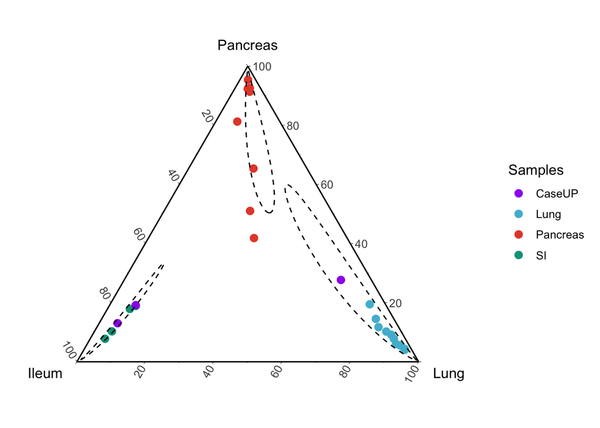

```r
localTestLRprob<-as.data.frame(predictLRlocaltestcohort$Prob)
colnames(localTestLRprob)<-c("Ileum", "Pancreas", "Lung")
ggtern(data = localTestLRprob, mapping = aes_string(x = "Ileum", y = "Pancreas", z = "Lung"))+
  scale_color_manual(values = c("purple", "#4DBBD5B2","#E64B35B2","#00A087B2"))+
    geom_point(aes(color = annoinputlocaltest[,"Sample_Group"]),size = 3, pch=16, alpha = 1)+
  scale_alpha(guide = 'none')+
  geom_confidence_tern(data = circle.df4, color="black", alpha = 1, linetype = 2,   breaks = c(0.95))+
  geom_confidence_tern(data = circle.df5, color="black", alpha = 1, linetype = 2,   breaks = c(0.95))+
  geom_confidence_tern(data = circle.df6, color="black", alpha = 1, linetype = 2,   breaks = c(0.95))+
  theme_classic()+
  labs(color="Samples")
```

```r
ggsave("localTestcohortLRzoomfar.eps", path = "./09_finalmodel/", width = 30,
  height = 20,
  units = "in")
ggsave("localTestcohortLRzoomclose.eps", path = "./09_finalmodel/", width = 6,
  height = 4,
  units = "in")
```

```r
table(annoinputlocaltest[,"Sample_Group"],predictLRlocaltestcohort$Prediction)
```

```
##
##            IlealNET PanNET PulmNET
##   CaseUP          2      0       1
##   Lung            0      0      10
##   Pancreas        0      9       0
##   SI              4      0       0
```

# Testing case series NET-UP

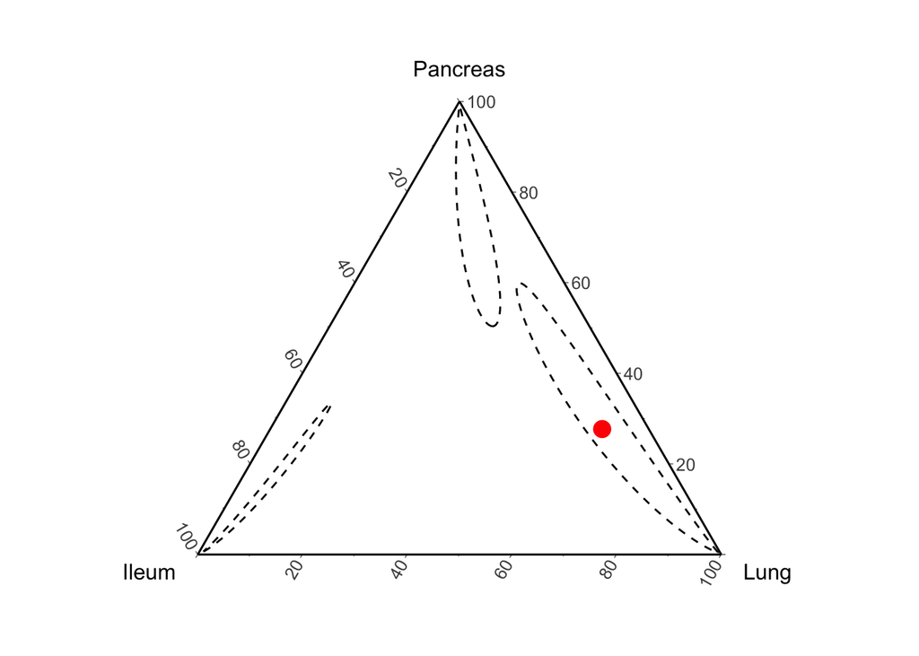

```r
TestLRprobNETUPcase<-as.data.frame(predictLRlocaltestcohort$Prob)
colnames(TestLRprobNETUPcase)<-c("Ileum", "Pancreas", "Lung")

TestLRprobNETUPcase1<-as.data.frame(TestLRprobNETUPcase)["Lung_NEN_MEN1",]
TestLRprobNETUPcase2<-as.data.frame(TestLRprobNETUPcase)["NET-UP",]
TestLRprobNETUPcase3<-as.data.frame(TestLRprobNETUPcase)["NET-UP2",]


ggtern(data = TestLRprobNETUPcase1, mapping = aes_string(x = "Ileum", y = "Pancreas", z = "Lung"))+
  geom_point(size = 4, pch=21, color="red", fill="red")+
  geom_confidence_tern(data = circle.df4, color="black", alpha = 1, linetype = 2,   breaks = c(0.95))+
  geom_confidence_tern(data = circle.df5, color="black", alpha = 1, linetype = 2,   breaks = c(0.95))+
  geom_confidence_tern(data = circle.df6, color="black", alpha = 1, linetype = 2,   breaks = c(0.95))+
  theme_classic()
```

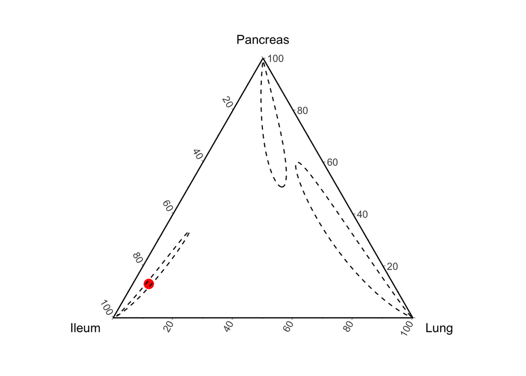

```r
ggsave("MEN1ternary.eps", path = "./09_finalmodel/", width = 4,
  height = 4,
  units = "in")

ggtern(data = TestLRprobNETUPcase2, mapping = aes_string(x = "Ileum", y = "Pancreas", z = "Lung"))+
  geom_point(size = 4, pch=21, color="red", fill="red")+
  geom_confidence_tern(data = circle.df4, color="black", alpha = 1, linetype = 2,   breaks = c(0.95))+
  geom_confidence_tern(data = circle.df5, color="black", alpha = 1, linetype = 2,   breaks = c(0.95))+
  geom_confidence_tern(data = circle.df6, color="black", alpha = 1, linetype = 2,   breaks = c(0.95))+
  theme_classic()
```

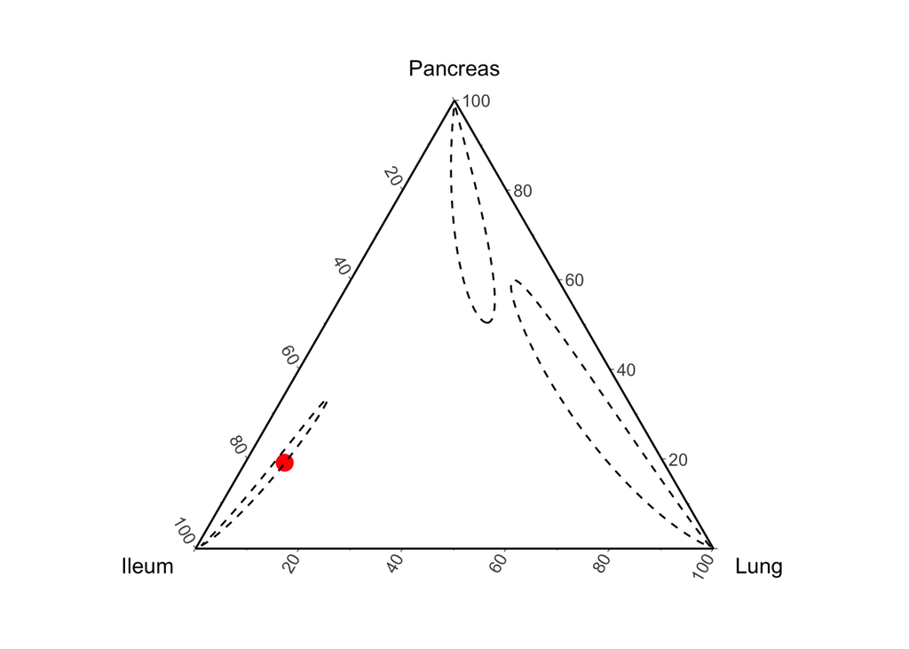

```r
ggsave("NETUP1ternary.eps", path = "./09_finalmodel/", width = 4,
  height = 4,
  units = "in")

ggtern(data = TestLRprobNETUPcase3, mapping = aes_string(x = "Ileum", y = "Pancreas", z = "Lung"))+
  geom_point(size = 4, pch=21, color="red", fill="red")+
  geom_confidence_tern(data = circle.df4, color="black", alpha = 1, linetype = 2,   breaks = c(0.95))+
  geom_confidence_tern(data = circle.df5, color="black", alpha = 1, linetype = 2,   breaks = c(0.95))+
  geom_confidence_tern(data = circle.df6, color="black", alpha = 1, linetype = 2,   breaks = c(0.95))+
  theme_classic()
```

```r
ggsave("NETUP2ternary.eps", path = "./09_finalmodel/", width = 4,
  height = 4,
  units = "in")
```

# Plot calibrated scores other NEN cohort with training set OOB calibrated tolerance ellipse

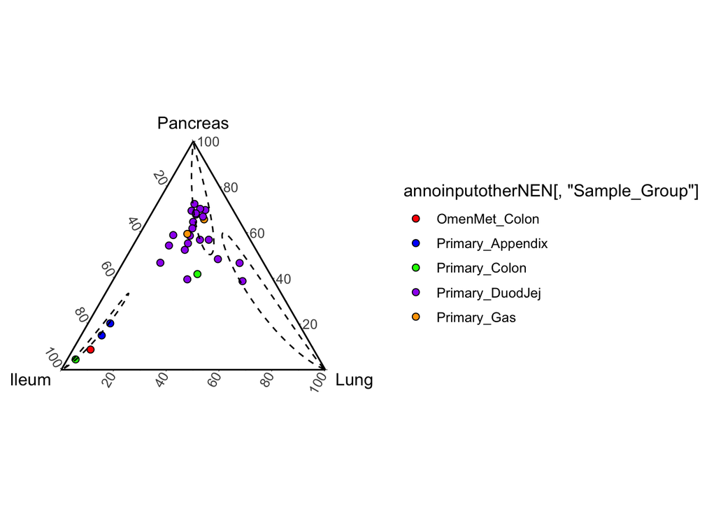

```r
otherNENLRprob<-as.data.frame(predictLRotherNENcohort$Prob)
colnames(otherNENLRprob)<-c("Ileum", "Pancreas", "Lung")
ggtern(data = otherNENLRprob, mapping = aes_string(x = "Ileum", y = "Pancreas", z = "Lung"))+
  scale_fill_manual(values = c("red","blue","green","purple","orange"))+
    geom_point(aes(fill = annoinputotherNEN[,"Sample_Group"]),size = 2, pch=21, color="black")+
  scale_alpha(guide = 'none')+
  geom_confidence_tern(data = circle.df4, color="black", alpha = 1, linetype = 2,   breaks = c(0.95))+
  geom_confidence_tern(data = circle.df5, color="black", alpha = 1, linetype = 2,   breaks = c(0.95))+
  geom_confidence_tern(data = circle.df6, color="black", alpha = 1, linetype = 2,   breaks = c(0.95))+
  theme_classic()
```

```r
ggsave("otherNENcohortzoomfar.eps", path = "./09_finalmodel/", width = 30,
  height = 20,
  units = "in")
ggsave("otherNENcohortzoomclose.eps", path = "./09_finalmodel/", width = 6,
  height = 4,
  units = "in")
```

# General stastistics model OOB

including oob mean and median votes for classes and distribution of class votes in training cohort

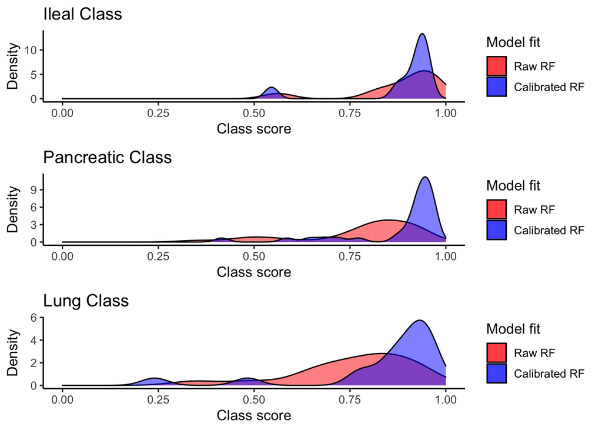

```r
oob<-cbind(as.data.frame(finalRF[[1]][[6]]),as.data.frame(as.character(finalRF[[1]][[16]])))
names(oob)[4]<-"Sample_Group"

oobsummary <- matrix(nrow=6, ncol=7)
oobsummary[1,1:6]<-summary(unlist(subset(oob, Sample_Group == "IlealNET", select=c(IlealNET))))
oobsummary[1,7]<-sd(unlist(subset(oob, Sample_Group == "IlealNET", select=c(IlealNET))))
oobsummary[2,1:6]<-summary(unlist(subset(oob, Sample_Group == "PanNET", select=c(PanNET))))
oobsummary[2,7]<-sd(unlist(subset(oob, Sample_Group == "PanNET", select=c(PanNET))))
oobsummary[3,1:6]<-summary(unlist(subset(oob, Sample_Group == "PulmNET", select=c(PulmNET))))
oobsummary[3,7]<-sd(unlist(subset(oob, Sample_Group == "PulmNET", select=c(PulmNET))))


LRprob<-cbind(as.data.frame(predict(finalLR$Ridgemodel, newx = finalRF[[1]][[6]], type = "response"),stringsAsFactors=FALSE),as.data.frame(as.character(finalRF[[1]][[16]])))
names(LRprob)<-c("IlealNET", "PanNET", "PulmNET", "Sample_Group")

oobsummary[4,1:6]<-summary(unlist(subset(LRprob, Sample_Group == "IlealNET", select=c(IlealNET))))
oobsummary[4,7]<-sd(unlist(subset(LRprob, Sample_Group == "IlealNET", select=c(IlealNET))))
oobsummary[5,1:6]<-summary(unlist(subset(LRprob, Sample_Group == "PanNET", select=c(PanNET))))
oobsummary[5,7]<-sd(unlist(subset(LRprob, Sample_Group == "PanNET", select=c(PanNET))))
oobsummary[6,1:6]<-summary(unlist(subset(LRprob, Sample_Group == "PulmNET", select=c(PulmNET))))
oobsummary[6,7]<-sd(unlist(subset(LRprob, Sample_Group == "PulmNET", select=c(PulmNET))))

plot1<-ggplot(as.data.frame(subset(oob, Sample_Group == "IlealNET")), aes(x=as.data.frame(subset(oob, Sample_Group == "IlealNET"))[,"IlealNET"], fill="red")) +
  geom_density(alpha=0.5)+
   geom_density(data=as.data.frame(subset(LRprob, Sample_Group == "IlealNET")),aes(x=as.data.frame(subset(LRprob, Sample_Group == "IlealNET"))[,"IlealNET"],fill="blue"), alpha=0.5)+
  xlim(0,1)+
  labs(x="Class score", y= "Density", title = "Ileal Class", fill = "Model")+
  scale_fill_identity(name = "Model fit",
                          breaks = c("red", "blue"),
                          labels = c("Raw RF", "Calibrated RF"),
                          guide = "legend")+
theme_classic()

plot2<-ggplot(as.data.frame(subset(oob, Sample_Group == "PanNET")), aes(x=as.data.frame(subset(oob, Sample_Group == "PanNET"))[,"PanNET"], fill="red")) +
  geom_density(alpha=0.5)+
   geom_density(data=as.data.frame(subset(LRprob, Sample_Group == "PanNET")),aes(x=as.data.frame(subset(LRprob, Sample_Group == "PanNET"))[,"PanNET"],fill="blue"), alpha=0.5)+
  xlim(0,1)+
  labs(x="Class score", y= "Density", title = "Pancreatic Class", fill = "Model")+
  scale_fill_identity(name = "Model fit",
                          breaks = c("red", "blue"),
                          labels = c("Raw RF", "Calibrated RF"),
                          guide = "legend")+
theme_classic()

plot3<-ggplot(as.data.frame(subset(oob, Sample_Group == "PulmNET")), aes(x=as.data.frame(subset(oob, Sample_Group == "PulmNET"))[,"PulmNET"], fill="red")) +
  geom_density(alpha=0.5)+
   geom_density(data=as.data.frame(subset(LRprob, Sample_Group == "PulmNET")),aes(x=as.data.frame(subset(LRprob, Sample_Group == "PulmNET"))[,"PulmNET"],fill="blue"), alpha=0.5)+
  xlim(0,1)+
  labs(x="Class score", y= "Density", title = "Lung Class", fill = "Model")+
  scale_fill_identity(name = "Model fit",
                          breaks = c("red", "blue"),
                          labels = c("Raw RF", "Calibrated RF"),
                          guide = "legend")+
theme_classic()

plot_grid(plot1, plot2, plot3, align = "v", nrow = 3, rel_heights = c(1/3, 1/3, 1/3))
```

```r
ggsave("classscoresOOB.pdf", path = "./09_finalmodel/", width = 6,
  height = 4,
  units = "in")


classscoresOOB<-as.data.frame(oobsummary, sort = FALSE)
row.names(classscoresOOB)<-c("ileal RF","pancreatic RF","lung RF", "ileal LR","pancreatic LR","lung LR")
colnames(classscoresOOB)<-c("Min.","1stQu.","Median", "Mean","3rdQu.","Max.", "SDev")
myfile <- file.path(paste0("./09_finalmodel/OOBsummaryFinalModel",".rData"))
save(classscoresOOB, file = myfile)
classscoresOOB
```

```
##                    Min.    1stQu.    Median      Mean    3rdQu.      Max.
## ileal RF      0.5567010 0.8557013 0.9211823 0.8799472 0.9606375 0.9759615
## pancreatic RF 0.3488372 0.7545987 0.8244579 0.7795004 0.8977501 0.9420849
## lung RF       0.3426966 0.6932190 0.7954518 0.7572019 0.8538891 0.9459459
## ileal LR      0.5450125 0.8976030 0.9309771 0.8856568 0.9452806 0.9501068
## pancreatic LR 0.4153636 0.9028360 0.9335388 0.8820028 0.9572664 0.9675098
## lung LR       0.2404376 0.8433530 0.9066623 0.8388628 0.9350090 0.9656334
##                    SDev
## ileal RF      0.1227142
## pancreatic RF 0.1566793
## lung RF       0.1579866
## ileal LR      0.1224111
## pancreatic LR 0.1316576
## lung LR       0.1874163
```

# General stastistics local test cohort

including mean and median votes for classes and distribution of class votes in local test cohort

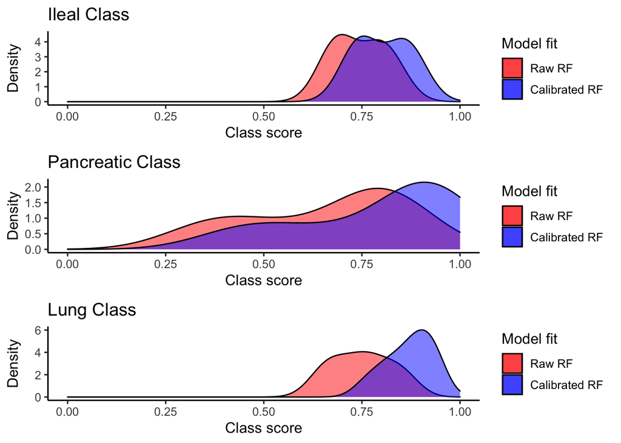

```r
scoresRFlocal<-cbind(as.data.frame(predictRFlocaltestcohort[[3]]),as.data.frame(as.character(annoinputlocaltest[,"Sample_Group"])))
names(scoresRFlocal)[4]<-"Sample_Group"

scoresRFlocalsummary <- matrix(nrow=6, ncol=7)
scoresRFlocalsummary[1,1:6]<-summary(unlist(subset(scoresRFlocal, Sample_Group == "SI", select=c(IlealNET))))
scoresRFlocalsummary[1,7]<-sd(unlist(subset(scoresRFlocal, Sample_Group == "SI", select=c(IlealNET))))
scoresRFlocalsummary[2,1:6]<-summary(unlist(subset(scoresRFlocal, Sample_Group == "Pancreas", select=c(PanNET))))
scoresRFlocalsummary[2,7]<-sd(unlist(subset(scoresRFlocal, Sample_Group == "Pancreas", select=c(PanNET))))
scoresRFlocalsummary[3,1:6]<-summary(unlist(subset(scoresRFlocal, Sample_Group == "Lung", select=c(PulmNET))))
scoresRFlocalsummary[3,7]<-sd(unlist(subset(scoresRFlocal, Sample_Group == "Lung", select=c(PulmNET))))


scoresLRlocal<-cbind(as.data.frame(predict(finalLR$Ridgemodel, newx = predictRFlocaltestcohort[[3]], type = "response"),stringsAsFactors=FALSE),as.data.frame(as.character(annoinputlocaltest[,"Sample_Group"])))
names(scoresLRlocal)<-c("IlealNET", "PanNET", "PulmNET", "Sample_Group")

scoresRFlocalsummary[4,1:6]<-summary(unlist(subset(scoresLRlocal, Sample_Group == "SI", select=c(IlealNET))))
scoresRFlocalsummary[4,7]<-sd(unlist(subset(scoresLRlocal, Sample_Group == "SI", select=c(IlealNET))))
scoresRFlocalsummary[5,1:6]<-summary(unlist(subset(scoresLRlocal, Sample_Group == "Pancreas", select=c(PanNET))))
scoresRFlocalsummary[5,7]<-sd(unlist(subset(scoresLRlocal, Sample_Group == "Pancreas", select=c(PanNET))))
scoresRFlocalsummary[6,1:6]<-summary(unlist(subset(scoresLRlocal, Sample_Group == "Lung", select=c(PulmNET))))
scoresRFlocalsummary[6,7]<-sd(unlist(subset(scoresLRlocal, Sample_Group == "Lung", select=c(PulmNET))))

plot1<-ggplot(as.data.frame(subset(scoresRFlocal, Sample_Group == "SI")), aes(x=as.data.frame(subset(scoresRFlocal, Sample_Group == "SI"))[,"IlealNET"], fill="red")) +
  geom_density(alpha=0.5)+
   geom_density(data=as.data.frame(subset(scoresLRlocal, Sample_Group == "SI")),aes(x=as.data.frame(subset(scoresLRlocal, Sample_Group == "SI"))[,"IlealNET"],fill="blue"), alpha=0.5)+
  xlim(0,1)+
  labs(x="Class score", y= "Density", title = "Ileal Class", fill = "Model")+
  scale_fill_identity(name = "Model fit",
                          breaks = c("red", "blue"),
                          labels = c("Raw RF", "Calibrated RF"),
                          guide = "legend")+
theme_classic()

plot2<-ggplot(as.data.frame(subset(scoresRFlocal, Sample_Group == "Pancreas")), aes(x=as.data.frame(subset(scoresRFlocal, Sample_Group == "Pancreas"))[,"PanNET"], fill="red")) +
  geom_density(alpha=0.5)+
   geom_density(data=as.data.frame(subset(scoresLRlocal, Sample_Group == "Pancreas")),aes(x=as.data.frame(subset(scoresLRlocal, Sample_Group == "Pancreas"))[,"PanNET"],fill="blue"), alpha=0.5)+
  xlim(0,1)+
  labs(x="Class score", y= "Density", title = "Pancreatic Class", fill = "Model")+
  scale_fill_identity(name = "Model fit",
                          breaks = c("red", "blue"),
                          labels = c("Raw RF", "Calibrated RF"),
                          guide = "legend")+
theme_classic()

plot3<-ggplot(as.data.frame(subset(scoresRFlocal, Sample_Group == "Lung")), aes(x=as.data.frame(subset(scoresRFlocal, Sample_Group == "Lung"))[,"PulmNET"], fill="red")) +
  geom_density(alpha=0.5)+
   geom_density(data=as.data.frame(subset(scoresLRlocal, Sample_Group == "Lung")),aes(x=as.data.frame(subset(scoresLRlocal, Sample_Group == "Lung"))[,"PulmNET"],fill="blue"), alpha=0.5)+
  xlim(0,1)+
  labs(x="Class score", y= "Density", title = "Lung Class", fill = "Model")+
  scale_fill_identity(name = "Model fit",
                          breaks = c("red", "blue"),
                          labels = c("Raw RF", "Calibrated RF"),
                          guide = "legend")+
theme_classic()

plot_grid(plot1, plot2, plot3, align = "v", nrow = 3, rel_heights = c(1/3, 1/3, 1/3))
```

```r
ggsave("classscoreslocaltest.pdf", path = "./09_finalmodel/", width = 6,
  height = 4,
  units = "in")


classscoreslocaltest<-as.data.frame(scoresRFlocalsummary, sort = FALSE)
row.names(classscoreslocaltest)<-c("ileal RF","pancreatic RF","lung RF", "ileal LR","pancreatic LR","lung LR")
colnames(classscoreslocaltest)<-c("Min.","1stQu.","Median", "Mean","3rdQu.","Max.", "SDev")
myfile <- file.path(paste0("./09_finalmodel/scoresRFlocalsummaryFinalModel",".rData"))
save(classscoreslocaltest, file = myfile)
classscoreslocaltest
```

```
##                    Min.    1stQu.    Median      Mean    3rdQu.      Max.
## ileal RF      0.6760000 0.6925000 0.7400000 0.7450000 0.7925000 0.8240000
## pancreatic RF 0.3340000 0.4920000 0.7740000 0.6562222 0.8000000 0.8820000
## lung RF       0.6440000 0.6855000 0.7520000 0.7498000 0.8020000 0.8540000
## ileal LR      0.7332301 0.7500770 0.8008656 0.8034256 0.8542142 0.8787411
## pancreatic LR 0.4184847 0.6538277 0.9137249 0.7820396 0.9253838 0.9540576
## lung LR       0.7597026 0.8314302 0.8811826 0.8700270 0.9148611 0.9387848
##                     SDev
## ileal RF      0.06971370
## pancreatic RF 0.20180546
## lung RF       0.07568619
## ileal LR      0.06998601
## pancreatic LR 0.20360540
## lung LR       0.05980826
```

# General stastistics online test cohort

including mean and median votes for classes and distribution of class votes in online test cohort

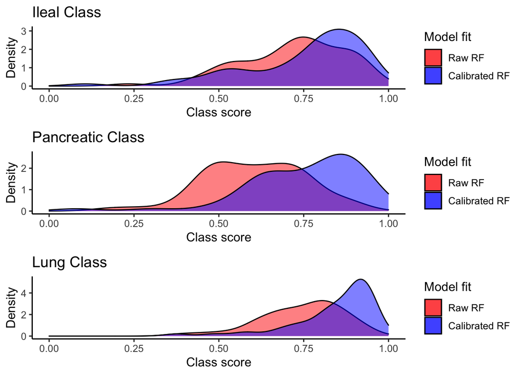

```r
scoresRFonline<-cbind(as.data.frame(predictRFonlinetestcohort[[3]]),as.data.frame(as.character(annoinputonlinetest[,"Sample_Group"])))
names(scoresRFonline)[4]<-"Sample_Group"
levels(scoresRFonline$Sample_Group) <- c("CaseUP", "SI", "SI","SI","Pancreas","SI","Lung","SI")

scoresRFonlinesummary <- matrix(nrow=6, ncol=7)
scoresRFonlinesummary[1,1:6]<-summary(unlist(subset(scoresRFonline, Sample_Group == "SI", select=c(IlealNET))))
scoresRFonlinesummary[1,7]<-sd(unlist(subset(scoresRFonline, Sample_Group == "SI", select=c(IlealNET))))


scoresRFonlinesummary[2,1:6]<-summary(unlist(subset(scoresRFonline, Sample_Group == "Pancreas", select=c(PanNET))))
scoresRFonlinesummary[2,7]<-sd(unlist(subset(scoresRFonline, Sample_Group == "Pancreas", select=c(PanNET))))
scoresRFonlinesummary[3,1:6]<-summary(unlist(subset(scoresRFonline, Sample_Group == "Lung", select=c(PulmNET))))
scoresRFonlinesummary[3,7]<-sd(unlist(subset(scoresRFonline, Sample_Group == "Lung", select=c(PulmNET))))


scoresLRonline<-cbind(as.data.frame(predict(finalLR$Ridgemodel, newx = predictRFonlinetestcohort[[3]], type = "response"),stringsAsFactors=FALSE),as.data.frame(as.character(annoinputonlinetest[,"Sample_Group"])))
names(scoresLRonline)<-c("IlealNET", "PanNET", "PulmNET", "Sample_Group")
levels(scoresLRonline$Sample_Group) <- c("CaseUP", "SI", "SI","SI","Pancreas","SI","Lung","SI")


scoresRFonlinesummary[4,1:6]<-summary(unlist(subset(scoresLRonline, Sample_Group == "SI", select=c(IlealNET))))
scoresRFonlinesummary[4,7]<-sd(unlist(subset(scoresLRonline, Sample_Group == "SI", select=c(IlealNET))))
scoresRFonlinesummary[5,1:6]<-summary(unlist(subset(scoresLRonline, Sample_Group == "Pancreas", select=c(PanNET))))
scoresRFonlinesummary[5,7]<-sd(unlist(subset(scoresLRonline, Sample_Group == "Pancreas", select=c(PanNET))))
scoresRFonlinesummary[6,1:6]<-summary(unlist(subset(scoresLRonline, Sample_Group == "Lung", select=c(PulmNET))))
scoresRFonlinesummary[6,7]<-sd(unlist(subset(scoresLRonline, Sample_Group == "Lung", select=c(PulmNET))))

plot1<-ggplot(as.data.frame(subset(scoresRFonline, Sample_Group == "SI")), aes(x=as.data.frame(subset(scoresRFonline, Sample_Group == "SI"))[,"IlealNET"], fill="red")) +
  geom_density(alpha=0.5)+
   geom_density(data=as.data.frame(subset(scoresLRonline, Sample_Group == "SI")),aes(x=as.data.frame(subset(scoresLRonline, Sample_Group == "SI"))[,"IlealNET"],fill="blue"), alpha=0.5)+
  xlim(0,1)+
  labs(x="Class score", y= "Density", title = "Ileal Class", fill = "Model")+
  scale_fill_identity(name = "Model fit",
                          breaks = c("red", "blue"),
                          labels = c("Raw RF", "Calibrated RF"),
                          guide = "legend")+
theme_classic()

plot2<-ggplot(as.data.frame(subset(scoresRFonline, Sample_Group == "Pancreas")), aes(x=as.data.frame(subset(scoresRFonline, Sample_Group == "Pancreas"))[,"PanNET"], fill="red")) +
  geom_density(alpha=0.5)+
   geom_density(data=as.data.frame(subset(scoresLRonline, Sample_Group == "Pancreas")),aes(x=as.data.frame(subset(scoresLRonline, Sample_Group == "Pancreas"))[,"PanNET"],fill="blue"), alpha=0.5)+
  xlim(0,1)+
  labs(x="Class score", y= "Density", title = "Pancreatic Class", fill = "Model")+
  scale_fill_identity(name = "Model fit",
                          breaks = c("red", "blue"),
                          labels = c("Raw RF", "Calibrated RF"),
                          guide = "legend")+
theme_classic()

plot3<-ggplot(as.data.frame(subset(scoresRFonline, Sample_Group == "Lung")), aes(x=as.data.frame(subset(scoresRFonline, Sample_Group == "Lung"))[,"PulmNET"], fill="red")) +
  geom_density(alpha=0.5)+
   geom_density(data=as.data.frame(subset(scoresLRonline, Sample_Group == "Lung")),aes(x=as.data.frame(subset(scoresLRonline, Sample_Group == "Lung"))[,"PulmNET"],fill="blue"), alpha=0.5)+
  xlim(0,1)+
  labs(x="Class score", y= "Density", title = "Lung Class", fill = "Model")+
  scale_fill_identity(name = "Model fit",
                          breaks = c("red", "blue"),
                          labels = c("Raw RF", "Calibrated RF"),
                          guide = "legend")+
theme_classic()

plot_grid(plot1, plot2, plot3, align = "v", nrow = 3, rel_heights = c(1/3, 1/3, 1/3))
```

```r
ggsave("classscoresonlinetest.pdf", path = "./09_finalmodel/", width = 6,
  height = 4,
  units = "in")


classscoresonlinetest<-as.data.frame(scoresRFonlinesummary, sort = FALSE)
row.names(classscoresonlinetest)<-c("ileal RF","pancreatic RF","lung RF", "ileal LR","pancreatic LR","lung LR")
colnames(classscoresonlinetest)<-c("Min.","1stQu.","Median", "Mean","3rdQu.","Max.", "SDev")
myfile <- file.path(paste0("./09_finalmodel/scoresRFonlinesummaryFinalModel",".rData"))
save(classscoresonlinetest, file = myfile)
classscoresonlinetest
```

```
##                     Min.    1stQu.    Median      Mean    3rdQu.      Max.
## ileal RF      0.23400000 0.6350000 0.7340000 0.7191864 0.8210000 0.9460000
## pancreatic RF 0.18000000 0.4900000 0.6160000 0.6040000 0.7210000 0.8940000
## lung RF       0.38200000 0.6710000 0.7630000 0.7430000 0.8290000 0.9400000
## ileal LR      0.10622938 0.6859455 0.8039444 0.7516898 0.8768104 0.9403561
## pancreatic LR 0.07960932 0.6501261 0.8025142 0.7523169 0.8823562 0.9570758
## lung LR       0.37486382 0.8073664 0.8871120 0.8426926 0.9263206 0.9634116
##                    SDev
## ileal RF      0.1520735
## pancreatic RF 0.1493259
## lung RF       0.1214249
## ileal LR      0.1787888
## pancreatic LR 0.1667995
## lung LR       0.1226991
```

# Average class scores known NETs vs predicted class scores unknown NETs

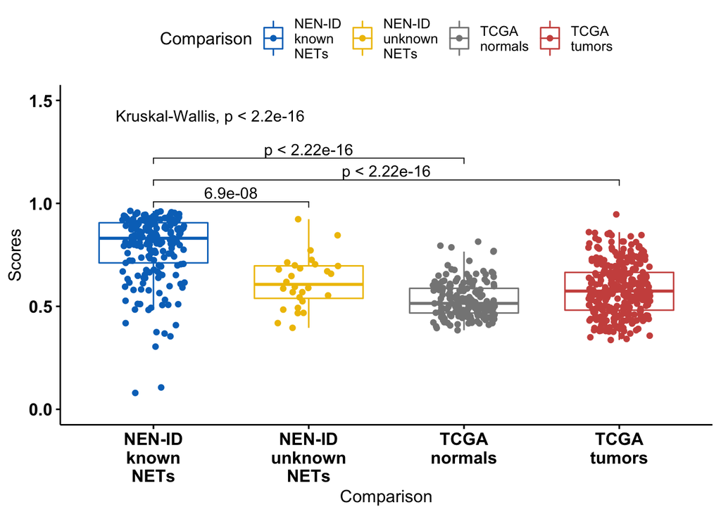

```r
# detach packages to achieve working plot with axis.
invisible(lapply(paste0("package:", names(sessionInfo()$otherPkgs)),
                 detach,
                 character.only = TRUE, unload = TRUE))
# reattach packages
library(ggpubr)
library(ggsci)

ScoresLR<-rbind(scoresLRlocal,scoresLRonline)

# of note, true origin is used for NEN-ID known NETs, this is why scores can be below 0.33
df1<-as.data.frame(subset(ScoresLR, Sample_Group == "SI", select=c("IlealNET", "Sample_Group")))
colnames(df1)[1]<-"Scores"
df2<-as.data.frame(subset(ScoresLR, Sample_Group == "Pancreas", select=c("PanNET", "Sample_Group")))
names(df2)[1]<-"Scores"
df3<-as.data.frame(subset(ScoresLR, Sample_Group == "Lung", select=c("PulmNET", "Sample_Group")))
names(df3)[1]<-"Scores"

# of note, predicted origin is used for NEN-ID unknown NETs and TCGA data, this is why all scores are above 0.33.
ScoresLRotherNEN<-cbind(as.data.frame(predictLRotherNENcohort[[3]]),as.data.frame(as.character(predictLRotherNENcohort[[4]])))
names(ScoresLRotherNEN)<-c("IlealNET", "PanNET", "PulmNET", "Sample_Group")
df4<-as.data.frame(subset(ScoresLRotherNEN, Sample_Group == "IlealNET", select=c("IlealNET", "Sample_Group")))
colnames(df4)[1]<-"Scores"
df5<-as.data.frame(subset(ScoresLRotherNEN, Sample_Group == "PanNET", c(select="PanNET", "Sample_Group")))
names(df5)[1]<-"Scores"
df6<-as.data.frame(subset(ScoresLRotherNEN, Sample_Group == "PulmNET", select=c("PulmNET", "Sample_Group")))
names(df6)[1]<-"Scores"

ScoresLRTCGAtumor<-cbind(as.data.frame(predictLRtcgatumorcohort[[3]]),as.data.frame(as.character(predictLRtcgatumorcohort[[4]])))
names(ScoresLRTCGAtumor)<-c("IlealNET", "PanNET", "PulmNET", "Sample_Group")
df7<-as.data.frame(subset(ScoresLRTCGAtumor, Sample_Group == "IlealNET", select=c("IlealNET", "Sample_Group")))
colnames(df7)[1]<-"Scores"
df8<-as.data.frame(subset(ScoresLRTCGAtumor, Sample_Group == "PanNET", select=c("PanNET", "Sample_Group")))
names(df8)[1]<-"Scores"
df9<-as.data.frame(subset(ScoresLRTCGAtumor, Sample_Group == "PulmNET", select=c("PulmNET", "Sample_Group")))
names(df9)[1]<-"Scores"

ScoresLRTCGAnormal<-cbind(as.data.frame(predictLRtcganormalcohort[[3]]),as.data.frame(as.character(predictLRtcganormalcohort[[4]])))
names(ScoresLRTCGAnormal)<-c("IlealNET", "PanNET", "PulmNET", "Sample_Group")
df10<-as.data.frame(subset(ScoresLRTCGAnormal, Sample_Group == "IlealNET", select=c("IlealNET", "Sample_Group")))
colnames(df10)[1]<-"Scores"
df11<-as.data.frame(subset(ScoresLRTCGAnormal, Sample_Group == "PanNET", select=c("PanNET", "Sample_Group")))
names(df11)[1]<-"Scores"
df12<-as.data.frame(subset(ScoresLRTCGAnormal, Sample_Group == "PulmNET", select=c("PulmNET", "Sample_Group")))
names(df12)[1]<-"Scores"

unrealscoresNEN<-as.data.frame(rbind(df4,df5,df6))
unrealscoresNEN$Comparison<-"NEN-ID unknown NETs"
unrealscoresTCGAtumor<-as.data.frame(rbind(df7,df8,df9))
unrealscoresTCGAtumor$Comparison<-"TCGA tumors"
unrealscoresTCGAnormal<-as.data.frame(rbind(df10,df11,df12))
unrealscoresTCGAnormal$Comparison<-"TCGA normals"
realscores<-as.data.frame(rbind(df1,df2,df3))
realscores$Comparison<-"NEN-ID known NETs"

scores<-rbind(realscores,unrealscoresNEN, unrealscoresTCGAtumor ,unrealscoresTCGAnormal)
scores$Comparison<-as.factor(scores$Comparison)
levels(scores$Comparison) <- gsub(" ", "\n", levels(scores$Comparison))
my_comparisons <- list(c("NEN-ID\nknown\nNETs", "NEN-ID\nunknown\nNETs"), c("NEN-ID\nknown\nNETs", "TCGA\ntumors"), c("NEN-ID\nknown\nNETs", "TCGA\nnormals"))
ggboxplot(scores, x = "Comparison", y = "Scores",
          color = "Comparison", palette = "jco",
          add = "jitter",
          ylim = c(0, 1.5))+
          theme(axis.text.x = element_text(face="bold",
                angle=0),
                axis.text.y = element_text(face="bold",
                angle=0))+
  stat_compare_means(comparisons = my_comparisons)+ # Add pairwise comparisons p-value
  stat_compare_means(label.y = 1.4)
```

```r
ggsave("WilcoxScore.eps", path = "./09_finalmodel/", width = 7.5, height = 5, units = "in")

# all calibrated scores including true origin/type
temp1<-merge(as.data.frame(predictLRotherNENcohort[[3]]),PD_otherNENcohort[,c("Sample_Name","Sample_Group")], by.x = "row.names", by.y = "Sample_Name")
rownames(temp1)<-temp1[,1]
temp1[,1]<-NULL
names(temp1)<-c("IlealNET", "PanNET", "PulmNET", "Sample_Group")
temp2<-merge(as.data.frame(predictLRtcgatumorcohort[[3]]),PD_data_tcga_primaries[,c("basename","tissue")], by.x = "row.names", by.y = "basename")
rownames(temp2)<-temp2[,1]
temp2[,1]<-NULL
names(temp2)<-c("IlealNET", "PanNET", "PulmNET", "Sample_Group")
temp3<-merge(as.data.frame(predictLRtcganormalcohort[[3]]),PD_data_tcga_normal[,c("basename","tissue")], by.x = "row.names", by.y = "basename")
rownames(temp3)<-temp3[,1]
temp3[,1]<-NULL
names(temp3)<-c("IlealNET", "PanNET", "PulmNET", "Sample_Group")
OverviewScores<-rbind(ScoresLR,temp1,temp2,temp3)
myfile <- file.path(paste0("./09_finalmodel/Cal_Scores_All_TestSamples",".rData"))
save(OverviewScores,scores, file = myfile)
```